# Heatmaps & density plots

## Overview

Heatmaps can be useful when tracking reporting metrics across many facilities/jurisdictions over time

For example, the image below shows % of weekdays that data was received from each facility, week-by-week:

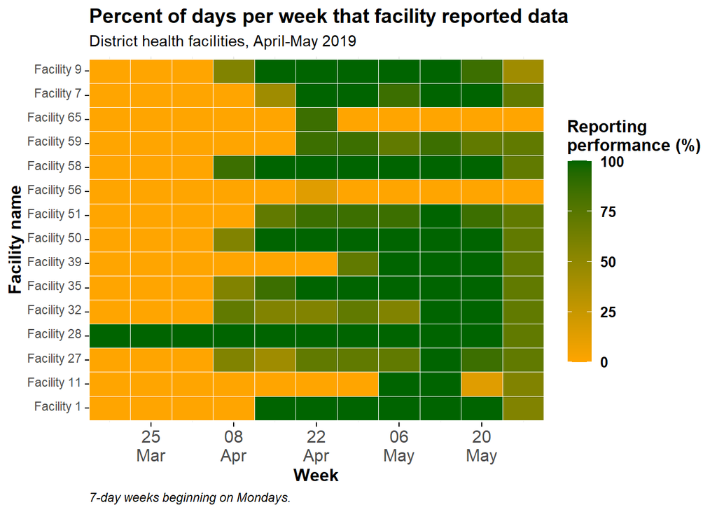

[figure not shown]

## Preparation

```r
pacman::p_load(OpenStreetMap,
               aweek)
```

## Reporting metrics over time

## Reporting metrics over time

Often in public health, an objective is to assess trends over time for many entities (facilities, jurisdictions, etc.). One way to visualize trends over time from many entities is a heatmap where the x-axis is time and the y-axis are the many entities.

### Preparation

### Preparation

To demonstrate this, we import this dataset of daily malaria case reports from 65 facilities.

The preparation will involve:

- Importing and reviewing the data
- Aggregating the daily data into weekly, and summarizing weekly performance

#### Load and view

Below are the first 30 rows of these data:

| location_name | data_date | submitted_date | Province | District | malaria_rdt_0-4 | malaria_rdt_5-14 | malaria_rdt_15 | malaria_tot | newid |
| --- | --- | --- | --- | --- | --- | --- | --- | --- | --- |
| Facility 1 | 2019-06-13 | 2019-06-14 | North | Spring | 11 | 12 | 23 | 46 | 1 |
| Facility 2 | 2019-06-13 | 2019-06-14 | North | Bolo | 11 | 10 | 5 | 26 | 2 |
| Facility 3 | 2019-06-13 | 2019-06-14 | North | Dingo | 8 | 5 | 5 | 18 | 3 |
| Facility 4 | 2019-06-13 | 2019-06-14 | North | Bolo | 16 | 16 | 17 | 49 | 4 |
| Facility 5 | 2019-06-13 | 2019-06-14 | North | Bolo | 9 | 2 | 6 | 17 | 5 |
| Facility 6 | 2019-06-13 | 2019-06-14 | North | Dingo | 3 | 1 | 4 | 8 | 6 |
| Facility 6 | 2019-06-12 | 2019-06-14 | North | Dingo | 4 | 0 | 3 | 7 | 6 |
| Facility 5 | 2019-06-12 | 2019-06-14 | North | Bolo | 15 | 14 | 13 | 42 | 5 |
| Facility 5 | 2019-06-11 | 2019-06-14 | North | Bolo | 11 | 11 | 13 | 35 | 5 |
| Facility 5 | 2019-06-10 | 2019-06-14 | North | Bolo | 19 | 15 | 15 | 49 | 5 |

[output cut: 20 more lines]

#### Packages

The packages we will use are:

```r
pacman::p_load(tidyverse, # ggplot and data manipulation
               rio,       # importing data
               aweek)     # manage weeks
```

#### Aggregate and summarize

The objective is to transform the daily reports (seen in previous tab) into weekly reports with a summary of performance - in this case *the proportion of days per week that the facility reported any data* for **Spring District** from April-May 2019.

To achieve this:

1. Filter the data as appropriate (by place, date)
2. Create a week column using `date2week()` from package **aweek**
   - This function transforms dates to weeks, using a specified start date of each week (e.g. “Monday”)
   - The `floor_day =` argument means that dates are rounded into the week only (day of the week is not shown)
   - The `factor =` argument converts the new column to a factor - important because all possible weeks within the date range are designated as levels, even if there is no data for them currently.
3. The data are grouped by columns “location” and “week” to create analysis units of “facility-week”
4. The verb `summarize()` creates new columns to calculate reporting performance for each “facility-week”:
   - Number of days per week (7 - a static value)
   - Number of reports received from the facility-week (could be more than 7!)
   - Sum of malaria cases reported by the facility-week (just for interest)
   - Number of *unique* days in the facility-week for which there is data reported
   - **Percent of the 7 days per facility-week for which data was reported**
5. The dataframe is joined (`right_join()`) to a comprehensive list of all possible facility-week combinations, to make the dataset complete. The matrix of all possible combinations is created by applying `expand()` to those two columns of the dataframe as it is at that moment in the pipe chain (represented by “.”). Because a `right_join()` is used, all rows in the `expand()` dataframe are kept, and added to agg_weeks if necessary. These new rows appear with `NA` (missing) summarized values.

```r
# Create weekly summary dataset
agg_weeks <- facility_count_data %>%

  # filter the data as appropriate
  filter(District == "Spring",
         data_date < as.Date("2019-06-01")) %>%

  # Create week column from data_date
  mutate(week = aweek::date2week(data_date,
                                 start_date = "Monday",
                                 floor_day = TRUE,
                                 factor = TRUE)) %>%
  # Group into facility-weeks
  group_by(location_name, week, .drop = F) %>%

  # Create summary column on the grouped data
  summarize(n_days          = 7,                                          # 7 days per week
            n_reports       = dplyr::n(),                                 # number of reports received per week (could be >7)
            malaria_tot     = sum(malaria_tot, na.rm = T),                # total malaria cases reported
            n_days_reported = length(unique(data_date)),                  # number of unique days reporting per week
            p_days_reported = round(100*(n_days_reported / n_days))) %>%  # percent of days reporting

  # Ensure every possible facility-week combination appears in the data
  right_join(tidyr::expand(., week, location_name))    # "." represents the dataset at that moment in the pipe chain
```

### Create heatmap

### Create heatmap

The `ggplot()` is make using `geom_tile()`:

- Weeks on the x-axis is transformed to dates, allowing use of `scale_x_date()`
- location_name on the y-axis will show all facility names
- The `fill` is the performance for that facility-week (numeric)
- `scale_fill_gradient()` is used on the numeric fill, specifying colors for high, low, and `NA`
- `scale_x_date()` is used on the x-axis specifying labels every 2 weeks and their format
- Aesthetic themes and labels can be adjusted as necessary

#### Basic

#### Basic

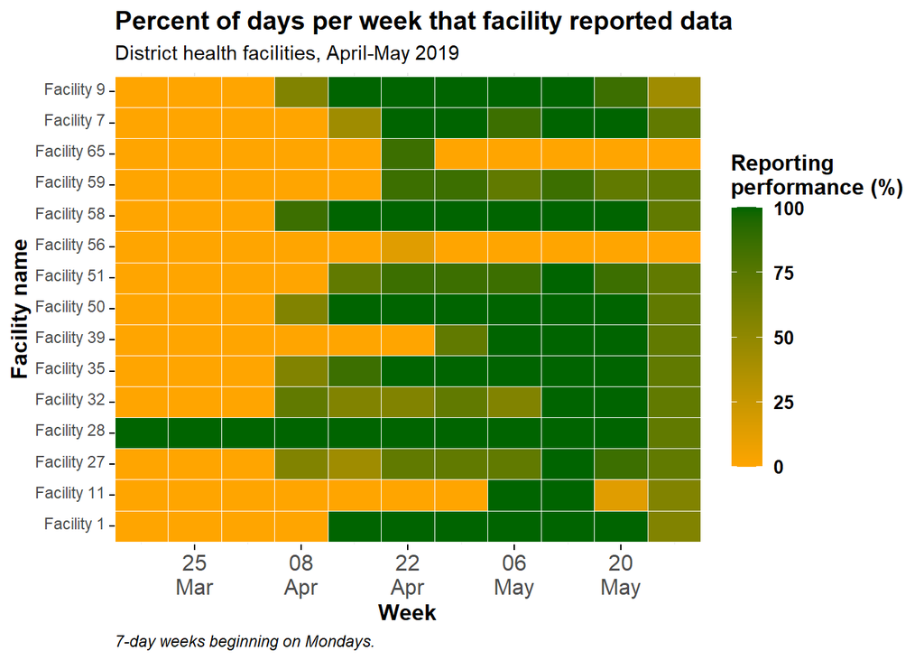

```r
ggplot(agg_weeks,
       aes(x = aweek::week2date(week),            # transformed to date class
           y = location_name,
           fill = p_days_reported))+
  # tiles
  geom_tile(colour="white")+                      # white gridlines

  scale_fill_gradient(low = "orange", high = "darkgreen", na.value = "grey80")+
  scale_x_date(expand = c(0,0),
               date_breaks = "2 weeks",
               date_labels = "%d\n%b")+

  # aesthetic themes
  theme_minimal()+                                  # simplify background
  theme(
    legend.title = element_text(size=12, face="bold"),
    legend.text  = element_text(size=10, face="bold"),
    legend.key.height = grid::unit(1,"cm"),         # height of legend key
    legend.key.width  = grid::unit(0.6,"cm"),       # width of legend key

    axis.text.x = element_text(size=12),
    axis.text.y = element_text(vjust=0.2),
    axis.ticks = element_line(size=0.4),
    axis.title = element_text(size=12, face="bold"),

    plot.title = element_text(hjust=0,size=14,face="bold"),
    plot.caption = element_text(hjust = 0, face = "italic")
    )+

  # plot labels
  labs(x = "Week",
       y = "Facility name",
       fill = "Reporting\nperformance (%)", # legend title
       title = "Percent of days per week that facility reported data",
       subtitle = "District health facilities, April-May 2019",
       caption = "7-day weeks beginning on Mondays.")
```

#### Ordered y-axis

#### Ordered y-axis

If you want to order the y-axis facilities by something, convert them to class Factor and provide the order. Below, the order is set based on the total number of reporting days filed by the facility across the whole timespan:

```r
facility_order <- agg_weeks %>%
  group_by(location_name) %>%
  summarize(tot_reports = sum(n_days_reported, na.rm=T)) %>%
  arrange(tot_reports) # ascending order
```

```r
as.tibble(facility_order)
```

```
## # A tibble: 15 x 2
##    location_name tot_reports
##    <chr>               <int>
##  1 Facility 56             1
##  2 Facility 65             6
##  3 Facility 11            19
##  4 Facility 39            31
##  5 Facility 59            33
##  6 Facility 27            40
##  7 Facility 32            41
##  8 Facility 51            41
##  9 Facility 7             42
## 10 Facility 1             46
## 11 Facility 9             48
## 12 Facility 35            50
## 13 Facility 50            51
## 14 Facility 58            53
## 15 Facility 28            75
```

Now use the above vector (`facility_order$location_name`) to be the order of the factor levels of location_name in the dataset `agg_weeks`:

```r
agg_weeks <- agg_weeks %>%
  mutate(location_name = factor(location_name, levels = facility_order$location_name))
```

And now the data are re-plotted, with location_name being an ordered factor:

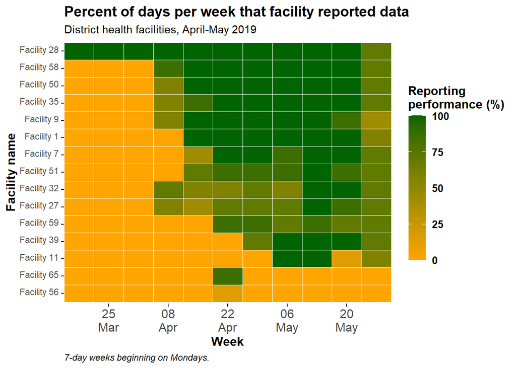

```r
ggplot(agg_weeks,
       aes(x = aweek::week2date(week),            # transformed to date class
           y = location_name,
           fill = p_days_reported))+
  # tiles
  geom_tile(colour="white")+                      # white gridlines

  scale_fill_gradient(low = "orange", high = "darkgreen", na.value = "grey80")+
  scale_x_date(expand = c(0,0),
               date_breaks = "2 weeks",
               date_labels = "%d\n%b")+

  # aesthetic themes
  theme_minimal()+                                  # simplify background
  theme(
    legend.title = element_text(size=12, face="bold"),
    legend.text  = element_text(size=10, face="bold"),
    legend.key.height = grid::unit(1,"cm"),         # height of legend key
    legend.key.width  = grid::unit(0.6,"cm"),       # width of legend key

    axis.text.x = element_text(size=12),
    axis.text.y = element_text(vjust=0.2),
    axis.ticks = element_line(size=0.4),
    axis.title = element_text(size=12, face="bold"),

    plot.title = element_text(hjust=0,size=14,face="bold"),
    plot.caption = element_text(hjust = 0, face = "italic")
    )+

  # plot labels
  labs(x = "Week",
       y = "Facility name",
       fill = "Reporting\nperformance (%)", # legend title
       title = "Percent of days per week that facility reported data",
       subtitle = "District health facilities, April-May 2019",
       caption = "7-day weeks beginning on Mondays.")
```

#### Display values

#### Display values

You can add a `geom_text()` layer on top of the tiles, to display the actual numbers of each tile. Be aware this may not look pretty if you have many small tiles!

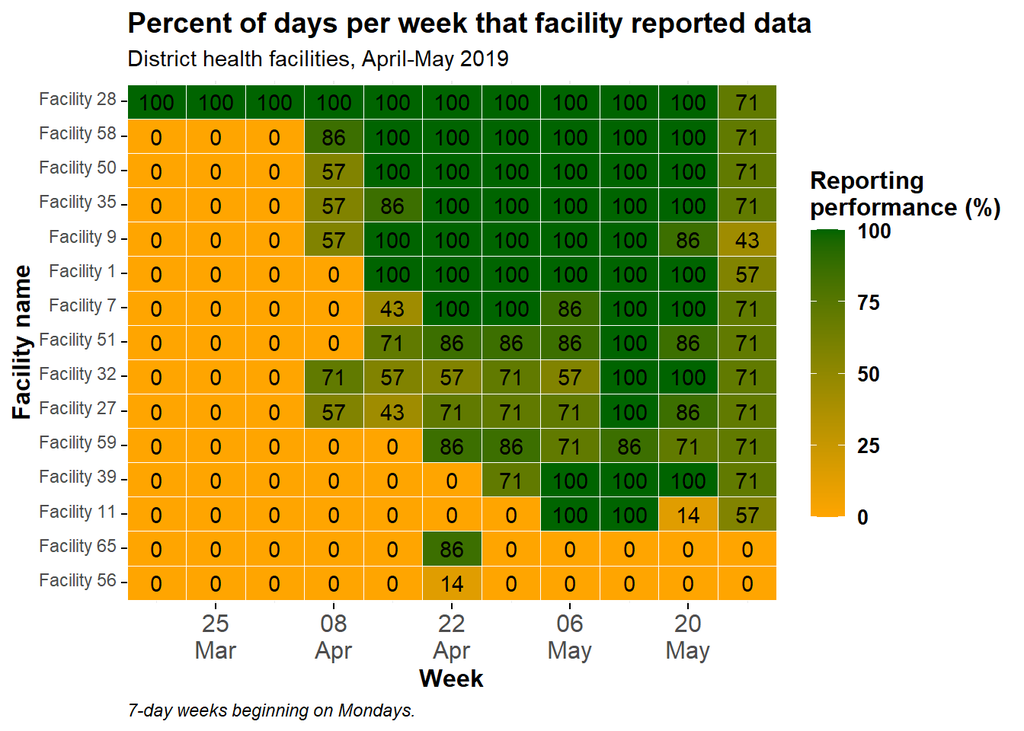

```r
ggplot(agg_weeks,
       aes(x = aweek::week2date(week),            # transformed to date class
           y = location_name,
           fill = p_days_reported))+
  # tiles
  geom_tile(colour="white")+                      # white gridlines

  geom_text(aes(label = p_days_reported))+          # add text on top of tile

  scale_fill_gradient(low = "orange", high = "darkgreen", na.value = "grey80")+
  scale_x_date(expand = c(0,0),
               date_breaks = "2 weeks",
               date_labels = "%d\n%b")+

  # aesthetic themes
  theme_minimal()+                                  # simplify background
  theme(
    legend.title = element_text(size=12, face="bold"),
    legend.text  = element_text(size=10, face="bold"),
    legend.key.height = grid::unit(1,"cm"),         # height of legend key
    legend.key.width  = grid::unit(0.6,"cm"),       # width of legend key

    axis.text.x = element_text(size=12),
    axis.text.y = element_text(vjust=0.2),
    axis.ticks = element_line(size=0.4),
    axis.title = element_text(size=12, face="bold"),

    plot.title = element_text(hjust=0,size=14,face="bold"),
    plot.caption = element_text(hjust = 0, face = "italic")
    )+

  # plot labels
  labs(x = "Week",
       y = "Facility name",
       fill = "Reporting\nperformance (%)", # legend title
       title = "Percent of days per week that facility reported data",
       subtitle = "District health facilities, April-May 2019",
       caption = "7-day weeks beginning on Mondays.")
```

## GIS heatmaps

Contoured heatmap of cases over a basemap

1. Create basemap tile from OpenStreetMap
2. Plot the cases from `linelist` using the latitude and longitude

http://data-analytics.net/cep/Schedule_files/geospatial.html

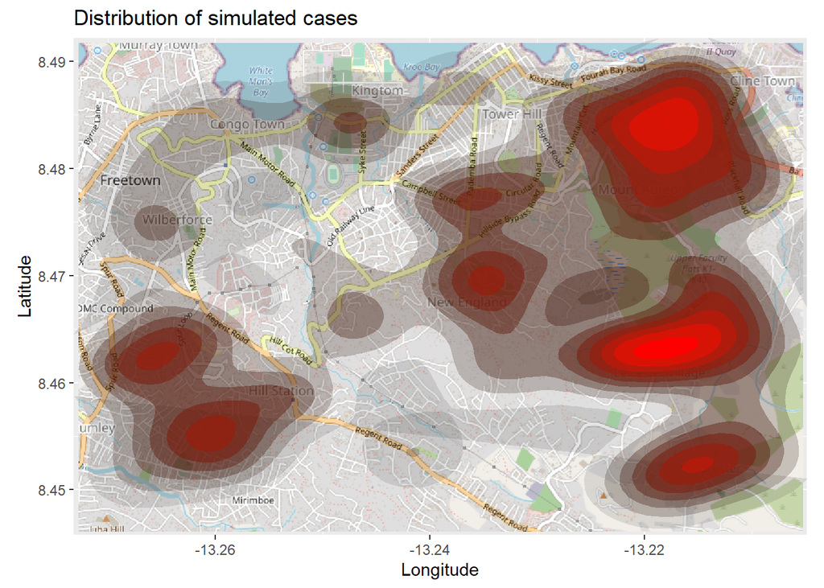

```r
pacman::p_load(OpenStreetMap)

# Fit basemap by range of lat/long coordinates. Choose tile type
map <- openmap(c(max(linelist$lat, na.rm=T), max(linelist$lon, na.rm=T)),  # limits of tile
               c(min(linelist$lat, na.rm=T), min(linelist$lon, na.rm=T)),
               zoom = NULL,
               type = c("osm", "stamen-toner", "stamen-terrain","stamen-watercolor", "esri","esri-topo")[1],
               mergeTiles = TRUE)

# Projection WGS84
map.latlon <- openproj(map, projection = "+proj=longlat +ellps=WGS84 +datum=WGS84 +no_defs")

# Plot map. Must be autoplotted to work with ggplot
OpenStreetMap::autoplot.OpenStreetMap(map.latlon)+
  # Density tiles
  ggplot2::stat_density_2d(aes(x = lon,
        y = lat,
        fill = ..level..,
        alpha=..level..),
    bins = 10,
    geom = "polygon",
    contour_var = "count",
    data = linelist,
    show.legend = F) +
  scale_fill_gradient(low = "black", high = "red")+
  labs(x = "Longitude",
       y = "Latitude",
       title = "Distribution of simulated cases")
```

https://www.rdocumentation.org/packages/OpenStreetMap/versions/0.3.4/topics/autoplot.OpenStreetMap

## Resources

This tab should stay with the name “Resources”. Links to other online tutorials or resources.